# Gestion des données

2024-04-10

# Objectifs

Apprendre à manipuler les données avec le tidyverse.

[Référence](https://r4ds.hadley.nz/) : Wickham, H. ; Grolemund, G. R for Data Science (2nd ed.) ; O’Reilly Media, 2023.

```r
library("tidyverse")
```

# Lecture des données

## Lecture d’un fichier

Fichier `.csv` au format anglo-saxon (séparateur décimal : `.`) :

```r
# Parcelle 15
read_csv("data/2023-09-29_ParacouP15AllYears.csv")
```

```
## # A tibble: 109,585 × 38
##    Forest   Plot PlotArea GeolPlot SubPlot TreeFieldNum idTree Xfield Yfield
##    <chr>   <dbl>    <dbl> <chr>      <dbl>        <dbl>  <dbl>  <dbl>  <dbl>
##  1 Paracou    15     6.25 Bonidoro       1            1 145312    3.5    131
##  2 Paracou    15     6.25 Bonidoro       1            1 145312    3.5    131
##  3 Paracou    15     6.25 Bonidoro       1            1 145312    3.5    131
##  4 Paracou    15     6.25 Bonidoro       1            1 145312    3.5    131
##  5 Paracou    15     6.25 Bonidoro       1            1 145312    3.5    131
##  6 Paracou    15     6.25 Bonidoro       1            1 145312    3.5    131
##  7 Paracou    15     6.25 Bonidoro       1            1 145312    3.5    131
##  8 Paracou    15     6.25 Bonidoro       1            1 145312    3.5    131
##  9 Paracou    15     6.25 Bonidoro       1            1 145312    3.5    131
## 10 Paracou    15     6.25 Bonidoro       1            1 145312    3.5    131
## # ℹ 109,575 more rows
## # ℹ 29 more variables: Xutm <dbl>, Yutm <dbl>, Lat <dbl>, Lon <dbl>,
## #   Family <chr>, Genus <chr>, Species <chr>, Author <chr>, Botanist <chr>,
## #   IdentYear <dbl>, FamilyFilled <chr>, GenusFilled <chr>,
## #   SpeciesFilled <chr>, AuthorFilled <chr>, BotaSource <chr>,
## #   BotaCertainty <dbl>, idVern <dbl>, VernName <chr>, CommercialSp <dbl>,
## #   CensusYear <dbl>, CensusDate <date>, CensusDateCertainty <dbl>, …
```

On obtient un tibble.

## Consolidation de toutes les données

Tous les tableaux ont le même format : on peut les empiler avec `bind_rows()`.

```r
# Parcelle 13
read_csv("data/2023-09-29_ParacouP13AllYears.csv") |>
  bind_rows(read_csv("data/2023-09-29_ParacouP14AllYears.csv")) |>
  bind_rows(read_csv("data/2023-09-29_ParacouP15AllYears.csv")) |>
  bind_rows(read_csv("data/2023-09-29_ParacouP16AllYears.csv")) |>
  print() ->
  paracou
```

```
## # A tibble: 410,050 × 38
##    Forest   Plot PlotArea GeolPlot SubPlot TreeFieldNum idTree Xfield Yfield
##    <chr>   <dbl>    <dbl> <chr>      <dbl>        <dbl>  <dbl>  <dbl>  <dbl>
##  1 Paracou    13     6.25 Bonidoro       1            1 136906    0.5    128
##  2 Paracou    13     6.25 Bonidoro       1            1 136906    0.5    128
##  3 Paracou    13     6.25 Bonidoro       1            1 136906    0.5    128
##  4 Paracou    13     6.25 Bonidoro       1            1 136906    0.5    128
##  5 Paracou    13     6.25 Bonidoro       1            1 136906    0.5    128
##  6 Paracou    13     6.25 Bonidoro       1            1 136906    0.5    128
##  7 Paracou    13     6.25 Bonidoro       1            1 136906    0.5    128
##  8 Paracou    13     6.25 Bonidoro       1            1 136906    0.5    128
##  9 Paracou    13     6.25 Bonidoro       1            1 136906    0.5    128
## 10 Paracou    13     6.25 Bonidoro       1            1 136906    0.5    128
## # ℹ 410,040 more rows
## # ℹ 29 more variables: Xutm <dbl>, Yutm <dbl>, Lat <dbl>, Lon <dbl>,
## #   Family <chr>, Genus <chr>, Species <chr>, Author <chr>, Botanist <chr>,
## #   IdentYear <dbl>, FamilyFilled <chr>, GenusFilled <chr>,
## #   SpeciesFilled <chr>, AuthorFilled <chr>, BotaSource <chr>,
## #   BotaCertainty <dbl>, idVern <dbl>, VernName <chr>, CommercialSp <dbl>,
## #   CensusYear <dbl>, CensusDate <date>, CensusDateCertainty <dbl>, …
```

Afficher le tableau, comprendre les colonnes. Chaque ligne contient une mesure de diamètre pour un arbre.

# Manipuler les données

Quelles sont les espèces les plus fréquentes ?

## Filtrer les lignes

Inventaire 2022 :

```r
paracou |>
  filter(CensusYear == 2022) |>
  print() ->
  paracou_2022
```

```
## # A tibble: 11,965 × 38
##    Forest   Plot PlotArea GeolPlot SubPlot TreeFieldNum idTree Xfield Yfield
##    <chr>   <dbl>    <dbl> <chr>      <dbl>        <dbl>  <dbl>  <dbl>  <dbl>
##  1 Paracou    13     6.25 Bonidoro       1            1 136906    0.5   128
##  2 Paracou    13     6.25 Bonidoro       1            2 136907   13     133
##  3 Paracou    13     6.25 Bonidoro       1            3 136908   12     132.
##  4 Paracou    13     6.25 Bonidoro       1            4 136909    9     134
##  5 Paracou    13     6.25 Bonidoro       1            5 136910    8.5   134.
##  6 Paracou    13     6.25 Bonidoro       1            6 136911    3     131
##  7 Paracou    13     6.25 Bonidoro       1            7 136912    1     130
##  8 Paracou    13     6.25 Bonidoro       1            8 136913    0.5   130.
##  9 Paracou    13     6.25 Bonidoro       1            9 136914    1.5   136
## 10 Paracou    13     6.25 Bonidoro       1           10 136915    4     137
## # ℹ 11,955 more rows
## # ℹ 29 more variables: Xutm <dbl>, Yutm <dbl>, Lat <dbl>, Lon <dbl>,
## #   Family <chr>, Genus <chr>, Species <chr>, Author <chr>, Botanist <chr>,
## #   IdentYear <dbl>, FamilyFilled <chr>, GenusFilled <chr>,
## #   SpeciesFilled <chr>, AuthorFilled <chr>, BotaSource <chr>,
## #   BotaCertainty <dbl>, idVern <dbl>, VernName <chr>, CommercialSp <dbl>,
## #   CensusYear <dbl>, CensusDate <date>, CensusDateCertainty <dbl>, …
```

Parcelle 15 :

```r
paracou_2022 |>
  filter(Plot == 15) |>
  print() ->
  paracou_2022_p15
```

```
## # A tibble: 4,214 × 38
##    Forest   Plot PlotArea GeolPlot SubPlot TreeFieldNum idTree Xfield Yfield
##    <chr>   <dbl>    <dbl> <chr>      <dbl>        <dbl>  <dbl>  <dbl>  <dbl>
##  1 Paracou    15     6.25 Bonidoro       1            1 145312    3.5   131
##  2 Paracou    15     6.25 Bonidoro       1            2 145313    4     131
##  3 Paracou    15     6.25 Bonidoro       1            3 145314    6     130
##  4 Paracou    15     6.25 Bonidoro       1            4 145315    9     126.
##  5 Paracou    15     6.25 Bonidoro       1            5 145316    4.5   132
##  6 Paracou    15     6.25 Bonidoro       1            8 145319    7.5   143
##  7 Paracou    15     6.25 Bonidoro       1            9 145320    8     143
##  8 Paracou    15     6.25 Bonidoro       1           10 145321    7.5   144.
##  9 Paracou    15     6.25 Bonidoro       1           13 145324    9     153
## 10 Paracou    15     6.25 Bonidoro       1           14 145325    5.5   156
## # ℹ 4,204 more rows
## # ℹ 29 more variables: Xutm <dbl>, Yutm <dbl>, Lat <dbl>, Lon <dbl>,
## #   Family <chr>, Genus <chr>, Species <chr>, Author <chr>, Botanist <chr>,
## #   IdentYear <dbl>, FamilyFilled <chr>, GenusFilled <chr>,
## #   SpeciesFilled <chr>, AuthorFilled <chr>, BotaSource <chr>,
## #   BotaCertainty <dbl>, idVern <dbl>, VernName <chr>, CommercialSp <dbl>,
## #   CensusYear <dbl>, CensusDate <date>, CensusDateCertainty <dbl>, …
```

## Sélectionner des colonnes

Données botaniques :

```r
paracou_2022_p15 |>
  select(idTree, Family:Species, Plot) |>
  print() ->
  paracou_2022_p15_bota
```

```
## # A tibble: 4,214 × 5
##    idTree Family        Genus      Species      Plot
##     <dbl> <chr>         <chr>      <chr>       <dbl>
##  1 145312 Myristicaceae Iryanthera hostmannii     15
##  2 145313 Caryocaraceae Caryocar   glabrum        15
##  3 145314 Malvaceae     Sterculia  pruriens       15
##  4 145315 Fabaceae      Eperua     falcata        15
##  5 145316 Lecythidaceae Lecythis   persistens     15
##  6 145319 Fabaceae      Eperua     grandiflora    15
##  7 145320 Bignoniaceae  Tabebuia   insignis       15
##  8 145321 Lecythidaceae Lecythis   persistens     15
##  9 145324 Fabaceae      Eperua     falcata        15
## 10 145325 Lecythidaceae Couratari  multiflora     15
## # ℹ 4,204 more rows
```

## Ajouter une colonne

Nom complet de l’espèce :

```r
paracou_2022_p15_bota |>
  mutate(espece = paste(Genus, Species)) |>
  print() ->
  paracou_2022_p15_bota_sp
```

```
## # A tibble: 4,214 × 6
##    idTree Family        Genus      Species      Plot espece
##     <dbl> <chr>         <chr>      <chr>       <dbl> <chr>
##  1 145312 Myristicaceae Iryanthera hostmannii     15 Iryanthera hostmannii
##  2 145313 Caryocaraceae Caryocar   glabrum        15 Caryocar glabrum
##  3 145314 Malvaceae     Sterculia  pruriens       15 Sterculia pruriens
##  4 145315 Fabaceae      Eperua     falcata        15 Eperua falcata
##  5 145316 Lecythidaceae Lecythis   persistens     15 Lecythis persistens
##  6 145319 Fabaceae      Eperua     grandiflora    15 Eperua grandiflora
##  7 145320 Bignoniaceae  Tabebuia   insignis       15 Tabebuia insignis
##  8 145321 Lecythidaceae Lecythis   persistens     15 Lecythis persistens
##  9 145324 Fabaceae      Eperua     falcata        15 Eperua falcata
## 10 145325 Lecythidaceae Couratari  multiflora     15 Couratari multiflora
## # ℹ 4,204 more rows
```

## Résumer

Combien d’arbres par espèce ?

```r
paracou_2022_p15_bota_sp |>
  group_by(espece) |>
  summarise(abondance = n()) |>
  print() ->
  paracou_2022_p15_bota_sp_abd
```

```
## # A tibble: 320 × 2
##    espece                  abondance
##    <chr>                       <int>
##  1 Abarema jupunba                 3
##  2 Agonandra silvatica             4
##  3 Albizia pedicellaris            4
##  4 Amaioua guianensis              3
##  5 Ambelania acida                15
##  6 Anacardium spruceanum           9
##  7 Anaxagorea dolichocarpa         2
##  8 Andira coriacea                10
##  9 Aniba taubertiana               3
## 10 Aniba williamsii                2
## # ℹ 310 more rows
```

## Trier

Par abondance décroissante :

```r
paracou_2022_p15_bota_sp_abd |>
  arrange(desc(abondance)) |>
  print() ->
  paracou_2022_p15_bota_sp_abd_dec
```

```
## # A tibble: 320 × 2
##    espece                     abondance
##    <chr>                          <int>
##  1 Eperua falcata                   374
##  2 Eschweilera sagotiana            310
##  3 Indet.Indet. Indet.              244
##  4 Lecythis persistens              213
##  5 Hymenopus heteromorphus          151
##  6 Oxandra asbeckii                 135
##  7 Pogonophora schomburgkiana       134
##  8 Licania alba                     130
##  9 Tapura capitulifera              130
## 10 Bocoa prouacensis                 81
## # ℹ 310 more rows
```

## Extraire une variable

Vecteur des espèces

```r
paracou_2022_p15_bota_sp_abd_dec |>
  # pull génère un vecteur
  pull(espece) |>
  # Affichage des premiers éléments
  head()
```

```
## [1] "Eperua falcata"          "Eschweilera sagotiana"
## [3] "Indet.Indet. Indet."     "Lecythis persistens"
## [5] "Hymenopus heteromorphus" "Oxandra asbeckii"
```

Combien y a-t-il d’arbres dans la parcelle 15 ?

```r
paracou_2022_p15_bota_sp_abd_dec |>
  # pull génère un vecteur
  pull(abondance) |>
  # Somme
  sum()
```

```
## [1] 4214
```

Remarque : le code classique peut être plus efficace pour des calculs simples :

```r
sum(paracou$Plot == 15 & paracou$CensusYear == 2022)
```

```
## [1] 4214
```

## Joindre plusieurs tables

Objectif : assembler les colonnes de plusieurs tables, pour les mêmes observations, grâce à une ou plusieurs colonnes d’identification.

Exemple : quelles espèces sont parmi les plus fréquentes à la fois dans les parcelles 13 et 15 ?

```r
paracou_2022 |>
  # Données bota et parcelle
  select(idTree, Family:Species, Plot) |>
  # Création de la colonne espece
  mutate(espece = paste(Genus, Species)) |>
  # Regroupement par parcelle et espèce
  group_by(Plot, espece) |>
  summarise(abondance = n()) |>
  # Abondance décroissante
  arrange(desc(abondance)) |>
  # Suppression des groupes pour les traitements suivants
  ungroup() ->
  # Espèces par parcelle en 2022
  paracou_2022_bota_dec
# Parcelle 13
paracou_2022_bota_dec |>
  # Filtrage de la parcelle
  filter(Plot == 13) |>
  # Renommer la variable abondance
  rename(abondance_p13 = abondance) |>
  # Supprimer la variable Plot
  select(!Plot) |>
  # Espèces les plus abondantes
  head(n = 5) |>
  print() ->
  paracou_2022_bota_p13_abd
```

```
## # A tibble: 5 × 2
##   espece                abondance_p13
##   <chr>                         <int>
## 1 Eperua falcata                  277
## 2 Indet.Indet. Indet.             268
## 3 Eschweilera sagotiana           251
## 4 Lecythis persistens             248
## 5 Licania alba                    191
```

```r
# Parcelle 15
paracou_2022_bota_dec |>
  # Filtrage de la parcelle
  filter(Plot == 15) |>
  # Renommer la variable abondance
  rename(abondance_p15 = abondance) |>
  # Supprimer la variable Plot
  select(!Plot) |>
  # Espèces les plus abondantes
  head(n = 5) |>
  print() ->
  paracou_2022_bota_p15_abd
```

```
## # A tibble: 5 × 2
##   espece                  abondance_p15
##   <chr>                           <int>
## 1 Eperua falcata                    374
## 2 Eschweilera sagotiana             310
## 3 Indet.Indet. Indet.               244
## 4 Lecythis persistens               213
## 5 Hymenopus heteromorphus           151
```

```r
# Jointure
paracou_2022_bota_p13_abd |>
  inner_join(paracou_2022_bota_p15_abd)
```

```
## # A tibble: 4 × 3
##   espece                abondance_p13 abondance_p15
##   <chr>                         <int>         <int>
## 1 Eperua falcata                  277           374
## 2 Indet.Indet. Indet.             268           244
## 3 Eschweilera sagotiana           251           310
## 4 Lecythis persistens             248           213
```

Voir `?inner_join` pour les jointures externes.

## Tableau long ou large

Les arbres sont mesurés plusieurs fois :

```r
# Premier arbre du jeu de données
paracou |>
  head(n = 1) |>
  pull(idTree)  |>
  print() ->
  id_premier
```

```
## [1] 136906
```

```r
# Enregistrements correspondants
paracou |>
  filter(idTree == id_premier) |>
  # Variables utiles : identifiant de l'arbre, année et mesure
  select(idTree, CensusYear, CircCorr) |>
  print() ->
  paracou_premier
```

```
## # A tibble: 26 × 3
##    idTree CensusYear CircCorr
##     <dbl>      <dbl>    <dbl>
##  1 136906       1991     135
##  2 136906       1992     135
##  3 136906       1993     135
##  4 136906       1994     135
##  5 136906       1995     135
##  6 136906       1997     136.
##  7 136906       1999     135
##  8 136906       2001     136
##  9 136906       2003     139
## 10 136906       2005     136
## # ℹ 16 more rows
```

Cette organisation des données en liste est un tableau *long*.

L’alternative est un tableau *large*, dans lequel chaque année est une colonne :

```r
paracou_premier |>
  pivot_wider(
    names_from = CensusYear,
    values_from = CircCorr
  )
```

```
## # A tibble: 1 × 27
##   idTree `1991` `1992` `1993` `1994` `1995` `1997` `1999` `2001` `2003` `2005`
##    <dbl>  <dbl>  <dbl>  <dbl>  <dbl>  <dbl>  <dbl>  <dbl>  <dbl>  <dbl>  <dbl>
## 1 136906    135    135    135    135    135   136.    135    136    139    136
## # ℹ 16 more variables: `2007` <dbl>, `2008` <dbl>, `2009` <dbl>, `2010` <dbl>,
## #   `2011` <dbl>, `2012` <dbl>, `2013` <dbl>, `2014` <dbl>, `2015` <dbl>,
## #   `2016` <dbl>, `2017` <dbl>, `2018` <dbl>, `2019` <dbl>, `2020` <dbl>,
## #   `2021` <dbl>, `2022` <dbl>
```

Les graphiques ggplot nécessitent des tableaux longs. Certains calculs sont plus simples avec des tableaux larges, par exemple les accroissements.

Exemple : accroissement moyen des arbres de la parcelle 15 entre la 1991 et 2022 (31 ans) :

```r
paracou |>
  # parcelle 15 |>
  filter(Plot == 15) |>
  # Colonnes de mesure
  select(idTree, CensusYear, CircCorr) |>
  # Tableau large
  pivot_wider(
    names_from = CensusYear,
    values_from = CircCorr
  ) |>
  # Années 1991 et 2022
  select(idTree, `1991`, `2022`) |>
  # Calcul de l'accroissement
  mutate(accroissement = `2022` - `1991`) |>
  # Élimination des données manquantes
  filter(!is.na(accroissement)) |>
  # Vecteur des accroissements
  pull(accroissement) |>
  # Moyenne
  mean() %>%
  # Division (pas très élégant, utiliser plutôt mutate avant)
  `/`(31)
```

```
## [1] 0.3330984
```

La croissance moyenne est d’un millimètre de diamètre par an (0,33 cm de circonférence).

# Flux de travail

Ecriture d’un pipeline complet, commenté, sans variables intermédiaire.

Quelles sont les espèces les plus abondantes dans la parcelle 15 de Paracou ?

```r
# Lecture et agrégation des fichiers de données
read_csv("data/2023-09-29_ParacouP13AllYears.csv") |>
  bind_rows(read_csv("data/2023-09-29_ParacouP14AllYears.csv")) |>
  bind_rows(read_csv("data/2023-09-29_ParacouP15AllYears.csv")) |>
  bind_rows(read_csv("data/2023-09-29_ParacouP16AllYears.csv")) |>
  # Filtrage de la parcelle 15 en 2022
  filter(Plot == 15 & CensusYear == 2022) |>
  # Sélection des données botaniques et de parcelle
  select(idTree, Family:Species, Plot) |>
  # Création de la variable espèce
  mutate(espece = paste(Genus, Species)) |>
  # Comptage des arbres
  group_by(espece) |>
  summarise(abondance = n()) |>
  # Tri par abondance décroissante
  arrange(desc(abondance)) |>
  # Affichage des 5 premières
  head(n = 5)
```

```
## # A tibble: 5 × 2
##   espece                  abondance
##   <chr>                       <int>
## 1 Eperua falcata                374
## 2 Eschweilera sagotiana         310
## 3 Indet.Indet. Indet.           244
## 4 Lecythis persistens           213
## 5 Hymenopus heteromorphus       151
```

Le flux s’écrit progressivement, donc lentement, ligne par ligne.

# Graphiques

Avec ggplot2. La variable d’entrée est un dataframe, qui peut provenir du flux de travail.

Affichage d’une courbe rang-abondance (diagramme de Whittaker) :

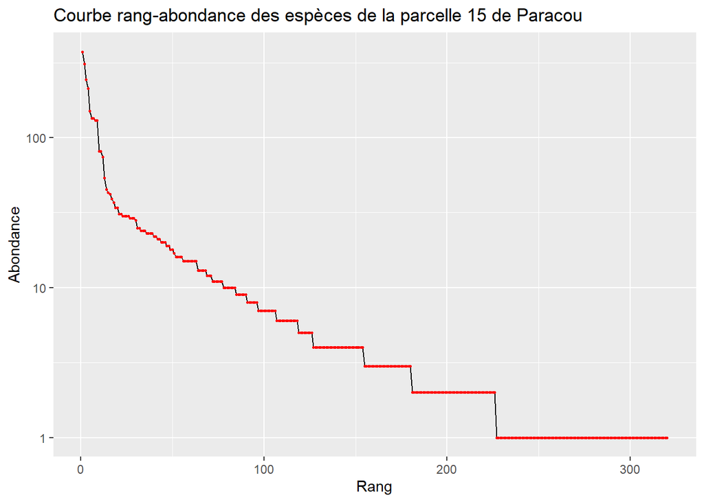

```r
paracou_2022_p15_bota_sp_abd_dec %>%
  # Ajout de la variable rang
  mutate(rang = seq_len(nrow(.))) |>
  # Graphique rang - abondance
  ggplot(aes(x = rang, y = abondance)) +
  # Courbe
  geom_line() +
  # Points rouges, petits, pour visualiser les espèces
  geom_point(col = "red", size = .5) +
  # Abondances en log
  scale_y_log10() +
  labs(
    title = "Courbe rang-abondance des espèces de la parcelle 15 de Paracou",
    x = "Rang",
    y = "Abondance"
  )
```

# Exercices

En moins de trois minutes, écrire le flux complet pour tracer la courbe rang-abondance globale des 4 parcelles de Paracou.

En prenant plus de temps, faire un histogramme de l’abondance des espèces les plus fréquentes, c’est à dire celles dont la fréquence est supérieure à 1%.

Aides :

- utiliser `filter()` pour filtrer les espèces abondantes. Exemple de code :

```r
# Paracou p15, inventaire de 2022
paracou_2022_p15_bota_sp_abd %>%
  # Calcul des fréquences des espèces
  mutate(frequence = abondance / sum(.$abondance)) |>
  # Filtrage
  filter(frequence >= 0.01)
```

```
## # A tibble: 15 × 3
##    espece                     abondance frequence
##    <chr>                          <int>     <dbl>
##  1 Bocoa prouacensis                 81    0.0192
##  2 Eperua falcata                   374    0.0888
##  3 Eschweilera sagotiana            310    0.0736
##  4 Gustavia hexapetala               74    0.0176
##  5 Hymenopus heteromorphus          151    0.0358
##  6 Indet.Indet. Indet.              244    0.0579
##  7 Lecythis persistens              213    0.0505
##  8 Licania alba                     130    0.0308
##  9 Licania membranacea               45    0.0107
## 10 Moronobea coccinea                54    0.0128
## 11 Oxandra asbeckii                 135    0.0320
## 12 Pogonophora schomburgkiana       134    0.0318
## 13 Recordoxylon speciosum            43    0.0102
## 14 Symphonia sp.1                    81    0.0192
## 15 Tapura capitulifera              130    0.0308
```

- le code pour créer un diagramme bâton est le suivant :

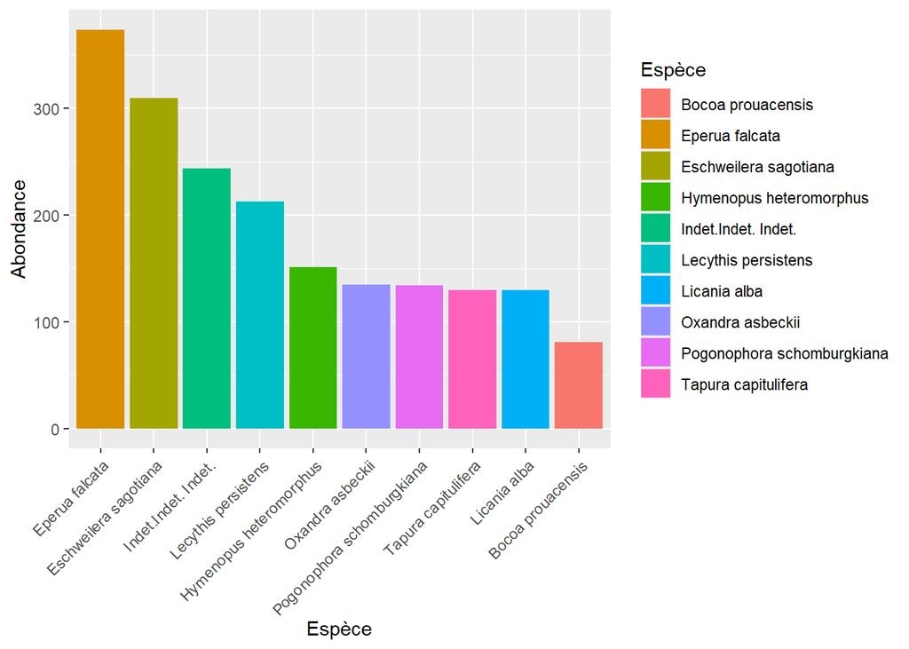

```r
# Parcelle 15, abondances décroissantes
paracou_2022_p15_bota_sp_abd_dec |>
  # 10 premières espèces
  head(n = 10) |>
  # Graphique
  ggplot() +
  # Bâtons dont la hauteur est la valeur de y
  geom_bar(
    # Statistique de calcul des bâtons: prendre seulement la valeur
    stat = "identity",
    aes(
      # Abscisse classée par ordre décroissant des abondances
      x = fct_rev(fct_reorder(espece, abondance)),
      y = abondance,
      # Couleur des bâtons, avec légende
      fill = espece
    )
  ) +
  # Étiquette des x inclinées et décalées
  theme(axis.text.x = element_text(angle = 45, vjust = 1, hjust = 1)) +
  # Étiquettes diverses
  labs(
    x = "Espèce",
    y = "Abondance",
    fill = "Espèce"
  )
```